# DadosJus: Libertando dados do Judiciário Brasileiro

# Paraíba

## MPPB - 2018 a 2020

### Verificando colunas

#### Agency ID

Todas as linhas possuem um valor para a coluna **aid**, e ele é sempre igual a “mppb”

```
## [1] TRUE
```

#### Month

O valor de **month** é maior que 0 e menor que 13 em todas as linhas (o json diz que o mínimo deve ser 0, e o máximo 12, possível erro)

```
## [1] TRUE
```

#### Year

O valor de **year** é igual a 2018, 2019 ou 2020 em todas as linhas (o json diz que o mínimo deve ser 0, possível erro(?))

```
## [1] TRUE
```

#### Name

Todas as linhas possuem um valor para a coluna **name**

```
## [1] TRUE
```

#### Role

Todas as linhas possuem um valor para a coluna **role**

```
## [1] TRUE
```

#### Type

As linhas da coluna **type**, segundo o json, devem ser de um dos seguintes tipos: “servidor”, “membro”, “pensionista” ou “indefinido”. No entanto, os tipos presentes são: “servidor”, “membro”, “pensionista” e “estagiario”.

| x |
| --- |
| estagiario |
| membro |
| pensionista |
| servidor |

Todas as linhas possuem um valor para a coluna **type**

```
## [1] TRUE
```

#### Income Total

Todas as linhas possuem um valor maior ou igual a 0 para a coluna **income_total**

```
## [1] TRUE
```

#### Perks Total

Todas as linhas possuem um valor maior ou igual a 0 para a coluna **perks_total**

```
## [1] TRUE
```

#### Sum of all funds

Todas as linhas possuem um valor maior ou igual a 0 para a coluna **funds_total**

```
## [1] TRUE
```

#### Total discounts

Todas as linhas possuem um valor maior ou igual a 0 para a coluna **discounts_total**

```
## [1] TRUE
```

#### Social security discounts

Todas as linhas possuem um valor maior ou igual a 0 para a coluna **discount_prev_contribution** (No json a variavel está escrita “discounts_prev_contribution”, possível erro)

```
## [1] TRUE
```

#### Demais colunas

As colunas **reg**, **workspace**, **active**, **wage**, **perks_food**, **perks_vacation**, **perks_transportation**, **perks_pre_school**, **perks_health**, **perks_birth**, **perks_housing**, **perks_subsistence**, **perks_compensatory_leave**, **perks_pecuniary**, **perks_vacation_pecuniary**, **perks_furniture_transport**, **perks_premium_license_pecuniary**, **funds_personal_benefits**, **funds_eventual_benefits**, **funds_trust_position**, **funds_daily**, **funds_gratification**, **funds_origin_pos**, **funds_others_total**, **discount_prev_contribution**, **discounts_ceil_retention**, **discounts_income_tax** e **discounts_others_total** não possuem nenhum tipo de regra de preenchimento no package. Mais abaixo têm-se algumas análises a respeito dos benefícios e indenizações.

## Análise Descritiva

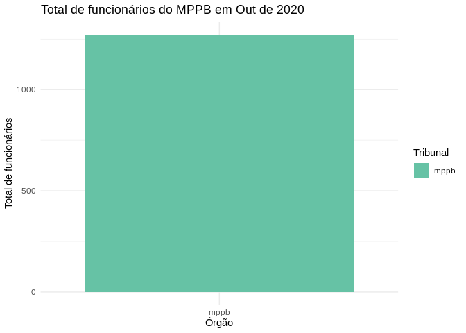

Os pagamentos medianos, máximos e mínimos se deram da seguinte forma.

|  | Mediana | Máximo | Mínimo |
| --- | --- | --- | --- |
| 2018 | 8159.08 | 89826.47 | 0 |
| 2019 | 9428.67 | 99526.22 | 0 |
| 2020 | 9511.96 | 65964.74 | 0 |

### Distribuição dos tipos de funcionários no MPPB de 2018 a 2020

No mês de outubro de 2018 o MPPB tinha **893** servidores, **77** pensionistas, **287** membros e **50** estagiários. Já no mês de outubro de 2019 o MPPB tinha **905** servidores, **78** pensionistas, **283** membros e **32** estagiários. Em outubro de 2020 o MPPB tinha **905** servidores, **80** pensionistas, **280** membros e **6** estagiários.

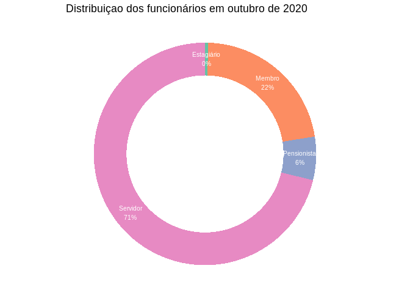

### Distribuição dos tipos dos gastos de 2018 a 2020

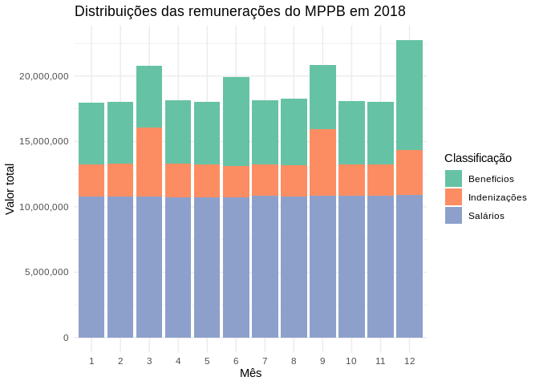

Os benefícios em novembro de 2019 superam os salários e as indenizações, somados.

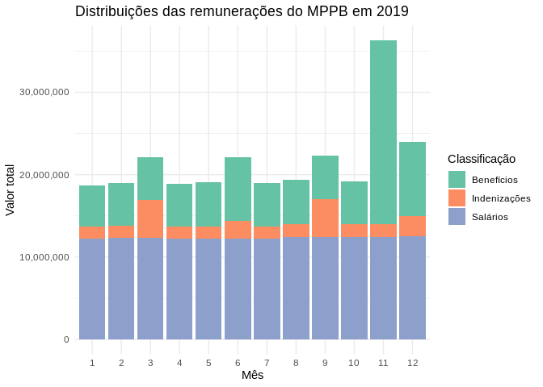

As remunerações de 2020 se comportam de forma semelhante a 2018, até o último mês disponível (outubro).

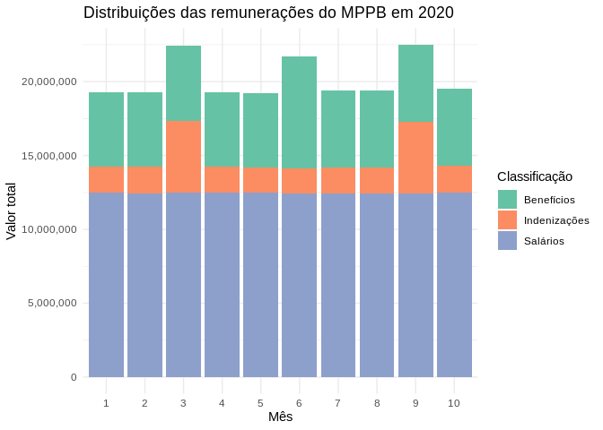

### Distribuição das remunerações dos funcionários de acordo com seu tipo

Em 2018 observa-se uma variação de 0 a R$ 45.000,00 nas remunerações.

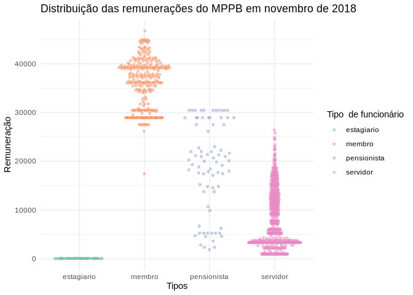

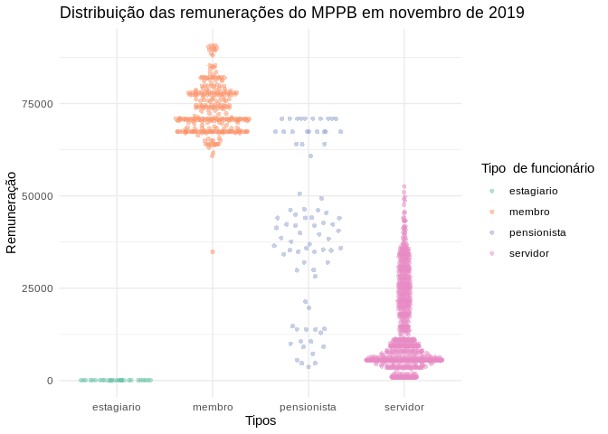

Em 2020 ainda não se têm os dados do mês equivalente (novembro), mas em outubro as remunerações se comportaram de forma semelhante ao mesmo período nos outros meses.

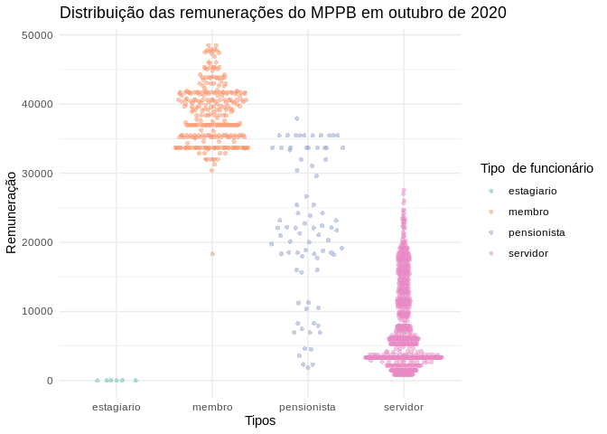

### Distribuição das remunerações de 2018 a 2020

Em 2018 observam-se poucas amostras com remuneração acima de R$ 75.000,00.

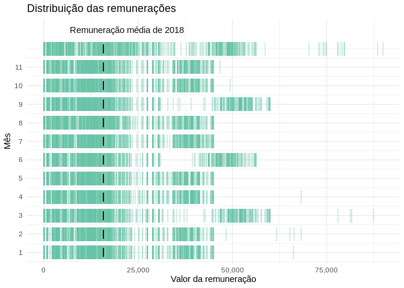

Como já foi exibido anteriormente, um número superior de remunerações acima de R$ 75.000,00 em 2019, em comparação com os outros anos.

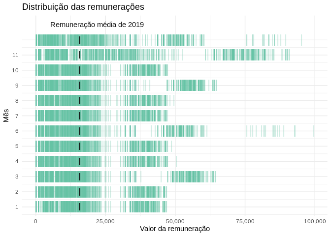

Em 2020 nenhuma remuneração chega à marca de R$ 75.000,00, até então.

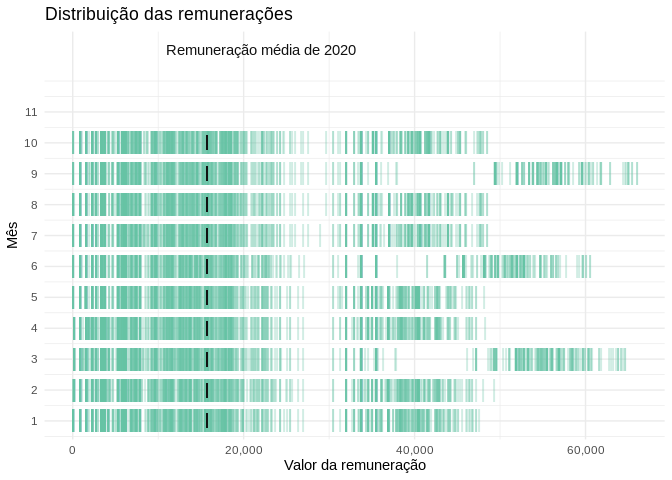

### Distribuição dos tipos de auxílios e indenizações

#### Benefícios

|  | Benefícios.Permanentes | Benefícios.Eventuais | Cargos.de.Confiança |
| --- | --- | --- | --- |
| 2018 | 33792586 | 11109729 | 18634650 |
| 2019 | 37468546 | 29484185 | 19158400 |
| 2020 | 32616070 | 4443936 | 16601721 |

Benefícios Permanentes (funds_personal_benefits) são os benefícios adquiridos judicialmente e outros benefícios pessoais, são a maior parcela paga em todos os anos. Benefícios Eventuais (funds_eventual_benefits), são benefícios como bônus de natal e férias. E Cargos de Confiança (funds_trust_position) são benefícios recebidos por funcionários em cargos de confiança.

Os outros benefícios, **funds_daily**, **funds_gratification**, **funds_origin_pos** e **funds_others_total**, não possuem valores associados (todos NA), em todos os anos.

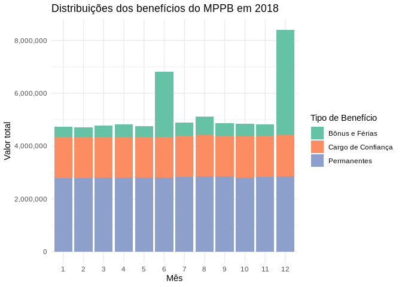

Aqui fica claro a fonte do aumento nos benefícios de novembro: Bônus e Férias. Mas ainda não explica a diferença com relação aos outros anos (talvez férias acumuladas? ou inconsistencia nos dados?).

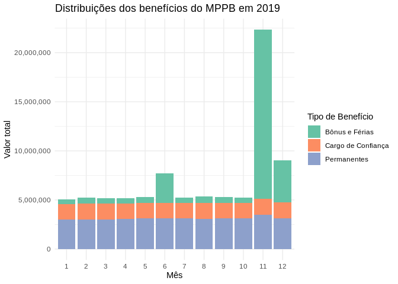

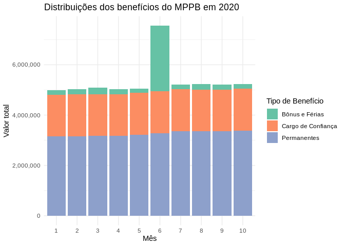

#### Indenizações

|  | Alimentação | Saúde | Compensações | Vantagem.e.Direito | Natalidade | Habitação |
| --- | --- | --- | --- | --- | --- | --- |
| 2018 | 11640253 | 1558495 | 0 | 11667220 | 160754.00 | 10804238 |
| 2019 | 11516160 | 1651022 | 0 | 12638829 | 0.00 | 0 |
| 2020 | 9667080 | 1431460 | 2032250 | 10564886 | 37168.32 | 0 |

Os auxílios presentes foram: Pagamentos por alguma vantagem e direito do servidor público (perks_pecuniary), que foi a maior parcela das verbas indenizatórias em todos os anos, bem como Auxílios Alimentação (perks_food), Auxílios Saúde (perks_health), Compensações por direito adquirido (perks_compensatory_leave), Auxílios Natalidade (perks_birth) e Auxílios Habitação (perks_housing).

Os outros benefícios não possuem valores associados. **perks_subsistence** tem todos os valores 0, em todos os anos, enquanto **perks_vacation**, **perks_transportation**, **perks_pre_school**, **perks_vacation_pecuniary**, **perks_furniture_transport**, **perks_premium_license_pecuniary** são todos NA, em todos os anos.

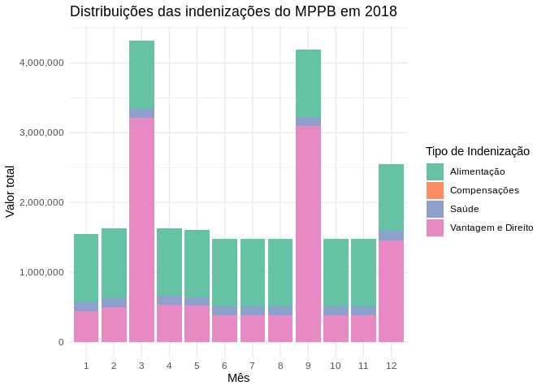

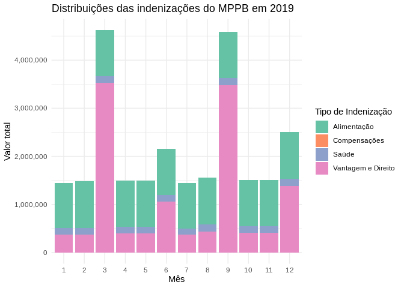

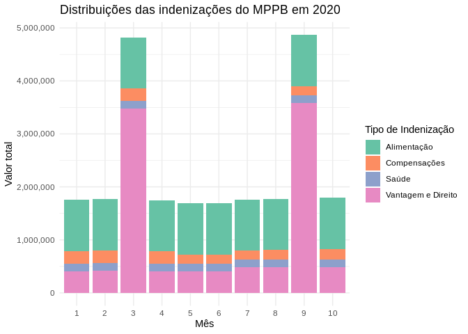

### Distribuição dos cargos em agosto de 2020

| Cargo | Quantidade |
| --- | --- |
| ASSESSOR V | 254 |
| TECNICO MINISTERIAL | 198 |
| PROMOTOR DE JUSTICA | 192 |
| À DISPOSIÇÃO | 144 |
| ANALISTA MINISTERIAL | 110 |
| PENSIONISTA DO PBPREV | 81 |
| TEC.MINIST.DELIG.APOIO ADMINIST | 68 |
| ASSESSOR IV | 50 |
| PROMOTOR DE JUSTICA DE 3ª ENTRÂNCIA - APOSENTADO(A) | 35 |
| ASSESSOR III | 21 |
| PROCURADOR DE JUSTICA | 19 |
| PROCURADOR DE JUSTICA - APOSENTADO(A) | 19 |
| TECNICO DE PROMOTORIA - APOSENTADO(A) | 15 |
| ASSESSOR | 11 |
| ESTAGIÁRIO | 10 |
| PROMOTOR DE JUSTICA DE 2ª ENTRÂNCIA - APOSENTADO(A) | 7 |
| OFICIAL DE PROMOTORIA II - APOSENTADO(A) | 6 |
| ANALISTA MINISTERIAL - APOSENTADO(A) | 5 |
| PROMOTOR DE JUSTICA DE 1ª ENTRÂNCIA - APOSENTADO(A) | 4 |
| TÉCNICO MINISTERIAL - APOSENTADO(A) | 4 |
| OFICIAL DE PROMOTORIA I - APOSENTADO(A) | 3 |
| TÉCNICO MINISTERIAL - DILIGÊNCIA E APOIO ADMINISTRATIVO - APOSENTADO(A) | 3 |
| OFICIAL DE DILIGENCIA I - APOSENTADO(A) | 2 |
| 1º PROMOTOR DE JUSTIÇA DA FAZENDA PÚBLICA DA PROMOTORIA DE JUSTIÇA DA FAZENDA PÚBLICA DE JOÃO PESSOA - APOSENTADO(A) | 1 |
| 5º PROCURADOR DE JUSTIÇA CÍVEL DA PROCURADORIA DE JUSTIÇA CÍVEL - APOSENTADO(A) | 1 |
| 5º PROMOTOR DE JUSTIÇA DA PROMOTORIA DE JUSTIÇA DE GUARABIRA - APOSENTADO(A) | 1 |
| 5º PROMOTOR DE JUSTIÇA DE DEFESA DA CRIANÇA E DO ADOLESCENTE DA PROMOTORIA DE JUSTIÇA DA CRIANÇA E DO ADOLESCENTE DE JOÃO PESSOA - APOSENTADO(A) | 1 |
| AGENTE DE PROMOTORIA - APOSENTADO(A) | 1 |
| ASSESSOR II | 1 |
| ASSESSOR VI AUXILIAR MILITAR | 1 |
| ASSESSOR VI MILITAR | 1 |
| AUXILIAR TECNICO DE PROMOTORIA - APOSENTADO(A) | 1 |
| OFICIAL DE DILIGENCIA II - APOSENTADO(A) | 1 |
| SEM DADOS | 1 |

[figure not shown]